# Building A Logistic Regression in Python, Step by Step

```python
import math
import numpy as np
import pandas as pd
from sklearn.linear_model import LogisticRegression
import statsmodels.api as sm
from sklearn import preprocessing
from sklearn.model_selection import train_test_split
from sklearn.metrics import confusion_matrix, classification_report, auc, roc_auc_score, roc_curve, accuracy_score
from optbinning import OptimalBinning
from optbinning import BinningProcess
from optbinning.scorecard import plot_auc_roc, plot_cap, plot_ks
import seaborn as sns
import matplotlib
import matplotlib.pyplot as plt
from IPython.display import display
# Config the matlotlib backend as plotting inline in IPython
%matplotlib inline
```

[output not shown]

```python
sns.set_theme(style="whitegrid")
```

### Data

```python
# data = pd.read_csv('banking.csv', header = 0)
# data.to_hdf('banking.h5', key='data', mode='w')
data = pd.read_hdf('banking.h5', 'data')
print(data.shape)
print(list(data.columns))
display(data)
```

```
(41188, 21)
['age', 'job', 'marital', 'education', 'default', 'housing', 'loan', 'contact', 'month', 'day_of_week', 'duration', 'campaign', 'pdays', 'previous', 'poutcome', 'emp_var_rate', 'cons_price_idx', 'cons_conf_idx', 'euribor3m', 'nr_employed', 'y']
```

|  | age | job | marital | education | default | housing | loan | contact | month | day_of_week | ... | campaign | pdays | previous | poutcome | emp_var_rate | cons_price_idx | cons_conf_idx | euribor3m | nr_employed | y |
| --- | --- | --- | --- | --- | --- | --- | --- | --- | --- | --- | --- | --- | --- | --- | --- | --- | --- | --- | --- | --- | --- |
| 0 | 44 | blue-collar | married | basic.4y | unknown | yes | no | cellular | aug | thu | ... | 1 | 999 | 0 | nonexistent | 1.4 | 93.444 | -36.1 | 4.963 | 5228.1 | 0 |
| 1 | 53 | technician | married | unknown | no | no | no | cellular | nov | fri | ... | 1 | 999 | 0 | nonexistent | -0.1 | 93.200 | -42.0 | 4.021 | 5195.8 | 0 |
| 2 | 28 | management | single | university.degree | no | yes | no | cellular | jun | thu | ... | 3 | 6 | 2 | success | -1.7 | 94.055 | -39.8 | 0.729 | 4991.6 | 1 |
| 3 | 39 | services | married | high.school | no | no | no | cellular | apr | fri | ... | 2 | 999 | 0 | nonexistent | -1.8 | 93.075 | -47.1 | 1.405 | 5099.1 | 0 |
| 4 | 55 | retired | married | basic.4y | no | yes | no | cellular | aug | fri | ... | 1 | 3 | 1 | success | -2.9 | 92.201 | -31.4 | 0.869 | 5076.2 | 1 |
| ... | ... | ... | ... | ... | ... | ... | ... | ... | ... | ... | ... | ... | ... | ... | ... | ... | ... | ... | ... | ... | ... |
| 41183 | 59 | retired | married | high.school | unknown | no | yes | telephone | jun | thu | ... | 1 | 999 | 0 | nonexistent | 1.4 | 94.465 | -41.8 | 4.866 | 5228.1 | 0 |
| 41184 | 31 | housemaid | married | basic.4y | unknown | no | no | telephone | may | thu | ... | 2 | 999 | 0 | nonexistent | 1.1 | 93.994 | -36.4 | 4.860 | 5191.0 | 0 |
| 41185 | 42 | admin. | single | university.degree | unknown | yes | yes | telephone | may | wed | ... | 3 | 999 | 0 | nonexistent | 1.1 | 93.994 | -36.4 | 4.857 | 5191.0 | 0 |
| 41186 | 48 | technician | married | professional.course | no | no | yes | telephone | oct | tue | ... | 2 | 999 | 0 | nonexistent | -3.4 | 92.431 | -26.9 | 0.742 | 5017.5 | 0 |
| 41187 | 25 | student | single | high.school | no | no | no | telephone | may | fri | ... | 4 | 999 | 0 | nonexistent | 1.1 | 93.994 | -36.4 | 4.859 | 5191.0 | 0 |

41188 rows × 21 columns

#### Input variables

- age (numeric)
- job : type of job (categorical: “admin”, “blue-collar”, “entrepreneur”, “housemaid”, “management”, “retired”, “self-employed”, “services”, “student”, “technician”, “unemployed”, “unknown”)
- marital : marital status (categorical: “divorced”, “married”, “single”, “unknown”)
- education (categorical: “basic.4y”, “basic.6y”, “basic.9y”, “high.school”, “illiterate”, “professional.course”, “university.degree”, “unknown”)
- default: has credit in default? (categorical: “no”, “yes”, “unknown”)
- housing: has housing loan? (categorical: “no”, “yes”, “unknown”)
- loan: has personal loan? (categorical: “no”, “yes”, “unknown”)
- contact: contact communication type (categorical: “cellular”, “telephone”)
- month: last contact month of year (categorical: “jan”, “feb”, “mar”, …, “nov”, “dec”)
- day_of_week: last contact day of the week (categorical: “mon”, “tue”, “wed”, “thu”, “fri”)
- duration: last contact duration, in seconds (numeric). Important note: this attribute highly affects the output target (e.g., if duration=0 then y=’no’). The duration is not known before a call is performed, also, after the end of the call, y is obviously known. Thus, this input should only be included for benchmark purposes and should be discarded if the intention is to have a realistic predictive model
- campaign: number of contacts performed during this campaign and for this client (numeric, includes last contact)
- pdays: number of days that passed by after the client was last contacted from a previous campaign (numeric; 999 means client was not previously contacted)
- previous: number of contacts performed before this campaign and for this client (numeric)
- poutcome: outcome of the previous marketing campaign (categorical: “failure”, “nonexistent”, “success”)
- emp.var.rate: employment variation rate — (numeric)
- cons.price.idx: consumer price index — (numeric)
- cons.conf.idx: consumer confidence index — (numeric)
- euribor3m: euribor 3 month rate — (numeric)
- nr.employed: number of employees — (numeric)

Predict variable (desired target):

- y — has the client subscribed a term deposit? (binary: “1”, means “Yes”, “0” means “No”)

```python
#check dtype of all columns
dtypes_dict = dict(data.dtypes)

for key, value in dtypes_dict.items():
    print(key, ': ', value)
```

```
age :  int64
job :  object
marital :  object
education :  object
default :  object
housing :  object
loan :  object
contact :  object
month :  object
day_of_week :  object
duration :  int64
campaign :  int64
pdays :  int64
previous :  int64
poutcome :  object
emp_var_rate :  float64
cons_price_idx :  float64
cons_conf_idx :  float64
euribor3m :  float64
nr_employed :  float64
y :  int64
```

The education column of the dataset has many categories and we need to reduce the categories for a better modelling. The education column has the following categories:

```python
data.groupby(['education']).size().reset_index(name='counts')
```

|  | education | counts |
| --- | --- | --- |
| 0 | basic.4y | 4176 |
| 1 | basic.6y | 2292 |
| 2 | basic.9y | 6045 |
| 3 | high.school | 9515 |
| 4 | illiterate | 18 |
| 5 | professional.course | 5243 |
| 6 | university.degree | 12168 |
| 7 | unknown | 1731 |

```python
data['education']=np.where(data['education'] =='basic.9y', 'Basic', data['education'])
data['education']=np.where(data['education'] =='basic.6y', 'Basic', data['education'])
data['education']=np.where(data['education'] =='basic.4y', 'Basic', data['education'])

data.groupby(['education']).size().reset_index(name='counts')
```

|  | education | counts |
| --- | --- | --- |
| 0 | Basic | 12513 |
| 1 | high.school | 9515 |
| 2 | illiterate | 18 |
| 3 | professional.course | 5243 |
| 4 | university.degree | 12168 |
| 5 | unknown | 1731 |

### Data exploration

```python
data.groupby(['y']).size().reset_index(name='counts')
```

|  | y | counts |
| --- | --- | --- |
| 0 | 0 | 36548 |
| 1 | 1 | 4640 |

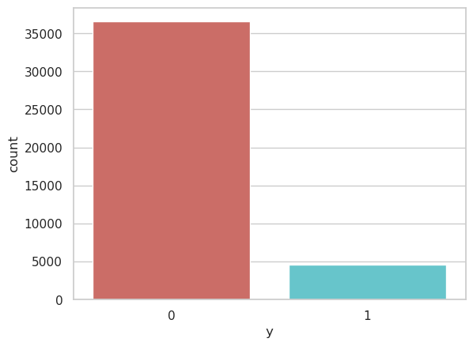

```python
sns.countplot(x = 'y', data = data, palette = 'hls')
```

```python
count_no_sub = len(data[data['y']==0])
count_sub = len(data[data['y']==1])
pct_of_no_sub = count_no_sub/(count_no_sub+count_sub)
print("percentage of no subscription is", round(pct_of_no_sub*100, 4))
pct_of_sub = 1 - pct_of_no_sub
print("percentage of subscription", round(pct_of_sub*100, 4))
```

```
percentage of no subscription is 88.7346
percentage of subscription 11.2654
```

### Visualizations

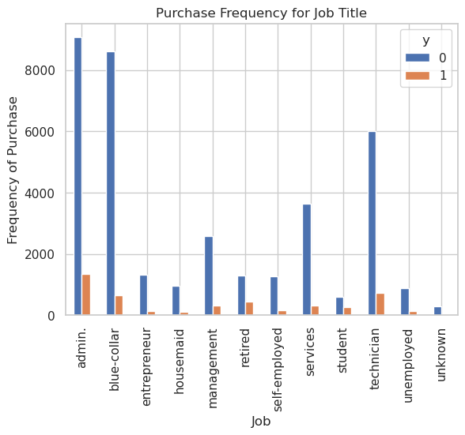

```python
pd.crosstab(data.job,data.y).plot(kind='bar')
plt.title('Purchase Frequency for Job Title')
plt.xlabel('Job')
plt.ylabel('Frequency of Purchase')
```

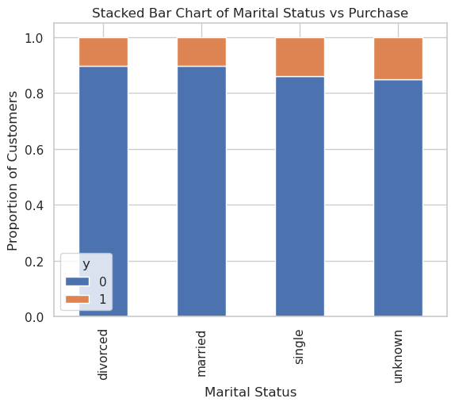

```python
table=pd.crosstab(data.marital,data.y)
table.div(table.sum(1).astype(float), axis=0).plot(kind='bar', stacked=True)
plt.title('Stacked Bar Chart of Marital Status vs Purchase')
plt.xlabel('Marital Status')
plt.ylabel('Proportion of Customers')
```

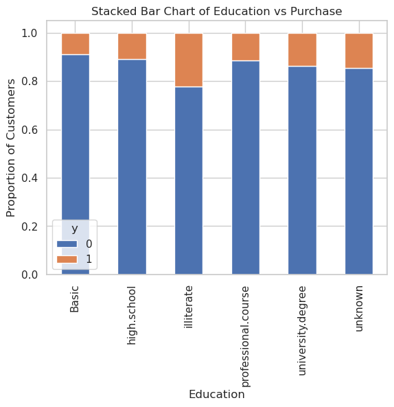

```python
table=pd.crosstab(data.education,data.y)
table.div(table.sum(1).astype(float), axis=0).plot(kind='bar', stacked=True)
plt.title('Stacked Bar Chart of Education vs Purchase')
plt.xlabel('Education')
plt.ylabel('Proportion of Customers')
```

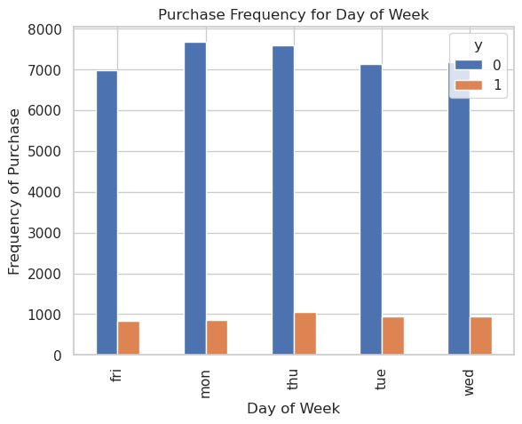

```python
pd.crosstab(data.day_of_week,data.y).plot(kind='bar')
plt.title('Purchase Frequency for Day of Week')
plt.xlabel('Day of Week')
plt.ylabel('Frequency of Purchase')
```

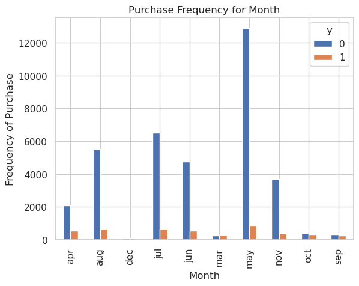

```python
pd.crosstab(data.month,data.y).plot(kind='bar')
plt.title('Purchase Frequency for Month')
plt.xlabel('Month')
plt.ylabel('Frequency of Purchase')
```

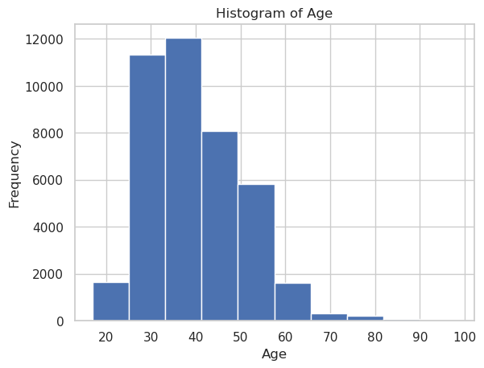

```python
data.age.hist()
plt.title('Histogram of Age')
plt.xlabel('Age')
plt.ylabel('Frequency')
```

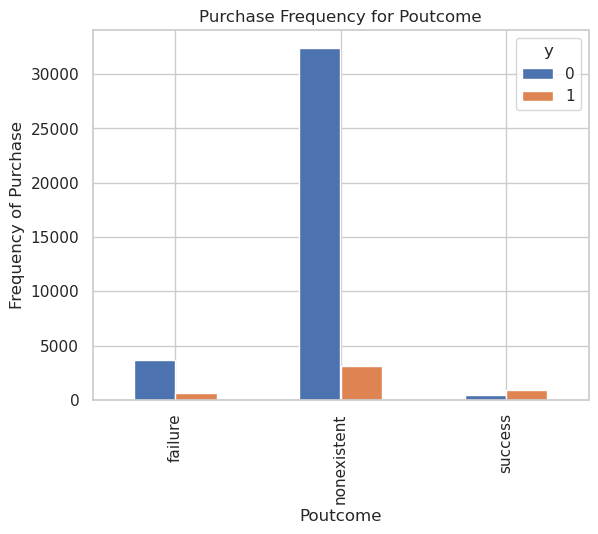

```python
pd.crosstab(data.poutcome,data.y).plot(kind='bar')
plt.title('Purchase Frequency for Poutcome')
plt.xlabel('Poutcome')
plt.ylabel('Frequency of Purchase')
```

### Logistic Regression Assumptions

- Binary logistic regression requires the dependent variable to be binary.
- For a binary regression, the factor level 1 of the dependent variable should represent the desired outcome.
- Only the meaningful variables should be included.
- The independent variables should be independent of each other. That is, the model should have little or no multicollinearity.
- The independent variables are linearly related to the log odds.
- Logistic regression requires quite large sample sizes.

```python
col = 'age'
x = data[col]
y = data['y']
optb = OptimalBinning(name = col, dtype = "numerical", solver = "cp")
optb.fit(x, y)
binning_table = optb.binning_table
print(type(binning_table))
print(optb.status)
print(optb.splits)
display(binning_table.build())
```

```
<class 'optbinning.binning.binning_statistics.BinningTable'>
OPTIMAL
[28.5 30.5 34.5 38.5 43.5 45.5 49.5 57.5]
```

|  | Bin | Count | Count (%) | Non-event | Event | Event rate | WoE | IV | JS |
| --- | --- | --- | --- | --- | --- | --- | --- | --- | --- |
| 0 | (-inf, 28.50) | 4216 | 0.102360 | 3480 | 736 | 0.174573 | -0.510355 | 0.032358 | 0.004001 |
| 1 | [28.50, 30.50) | 3167 | 0.076891 | 2779 | 388 | 0.122513 | -0.095071 | 0.000721 | 0.000090 |
| 2 | [30.50, 34.50) | 7371 | 0.178960 | 6573 | 798 | 0.108262 | 0.044705 | 0.000352 | 0.000044 |
| 3 | [34.50, 38.50) | 6421 | 0.155895 | 5820 | 601 | 0.093599 | 0.206549 | 0.006138 | 0.000766 |
| 4 | [38.50, 43.50) | 6068 | 0.147324 | 5578 | 490 | 0.080751 | 0.368268 | 0.017315 | 0.002152 |
| 5 | [43.50, 45.50) | 2114 | 0.051326 | 1945 | 169 | 0.079943 | 0.379206 | 0.006369 | 0.000791 |
| 6 | [45.50, 49.50) | 3776 | 0.091677 | 3487 | 289 | 0.076536 | 0.426458 | 0.014126 | 0.001753 |
| 7 | [49.50, 57.50) | 5823 | 0.141376 | 5253 | 570 | 0.097888 | 0.157006 | 0.003279 | 0.000409 |
| 8 | [57.50, inf) | 2232 | 0.054191 | 1633 | 599 | 0.268369 | -1.061 | 0.089563 | 0.010698 |
| 9 | Special | 0 | 0.000000 | 0 | 0 | 0.000000 | 0.0 | 0.000000 | 0.000000 |
| 10 | Missing | 0 | 0.000000 | 0 | 0 | 0.000000 | 0.0 | 0.000000 | 0.000000 |
| Totals |  | 41188 | 1.000000 | 36548 | 4640 | 0.112654 |  | 0.170221 | 0.020705 |

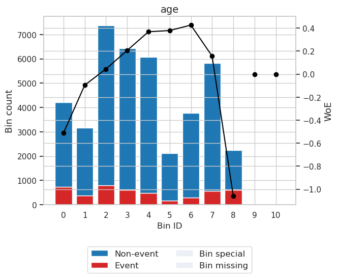

```python
binning_table.plot(metric="woe")
```

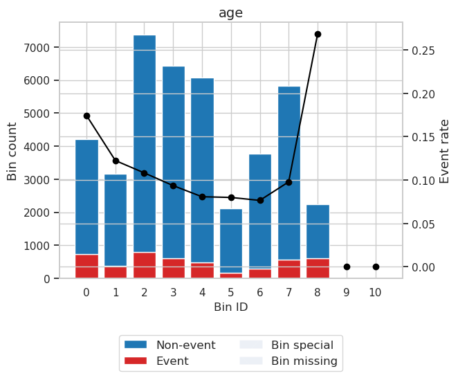

```python
binning_table.plot(metric="event_rate")
```

```python
binning_table.analysis(pvalue_test="chi2")
```

```
---------------------------------------------
OptimalBinning: Binary Binning Table Analysis
---------------------------------------------

  General metrics

    Gini index               0.20843003
    IV (Jeffrey)             0.17022083
    JS (Jensen-Shannon)      0.02070507
    Hellinger                0.02098438
    Triangular               0.08073794
    KS                       0.08441386
    HHI                      0.12838705
    HHI (normalized)         0.04122575
    Cramer's V               0.14594549
    Quality score            0.01989344

  Monotonic trend                valley

  Significance tests

    Bin A  Bin B  t-statistic      p-value      P[A > B]     P[B > A]
        0      1    37.976288 7.160966e-10  1.000000e+00 1.477707e-13
        1      2     4.504568 3.380444e-02  9.824470e-01 1.755296e-02
        2      3     8.094810 4.439219e-03  9.981266e-01 1.873393e-03
        3      4     6.459063 1.103878e-02  9.949222e-01 5.077838e-03
        4      5     0.013830 9.063838e-01  5.518493e-01 4.481507e-01
        5      6     0.219395 6.395012e-01  6.772816e-01 3.227184e-01
        6      7    12.816335 3.436061e-04  1.195917e-04 9.998804e-01
        7      8   377.989255 3.409848e-84 6.009220e-183 1.000000e+00
```

```python
all_variables = data.columns
all_dependent_variables = list(all_variables)
all_dependent_variables.remove('y')

category_variables = []

dtypes_dict = dict(data[all_dependent_variables].dtypes)

for key, value in dtypes_dict.items():
    if value == 'object':
        category_variables.append(key)

print(all_dependent_variables)
print(category_variables)
```

```
['age', 'job', 'marital', 'education', 'default', 'housing', 'loan', 'contact', 'month', 'day_of_week', 'duration', 'campaign', 'pdays', 'previous', 'poutcome', 'emp_var_rate', 'cons_price_idx', 'cons_conf_idx', 'euribor3m', 'nr_employed']
['job', 'marital', 'education', 'default', 'housing', 'loan', 'contact', 'month', 'day_of_week', 'poutcome']
```

```python
X = data[all_dependent_variables]
y = data[['y']]

X_train, X_test, y_train, y_test = train_test_split(X, y, stratify=y, test_size=0.3, random_state=1234)
```

```python
selection_criteria = {
    "iv": {"min": 0.3, "max": 1},
    "gini": {"min": 0.2}
}

binning_process = BinningProcess(variable_names = all_dependent_variables
                                 , max_n_prebins = 10
                                 , categorical_variables = category_variables
                                 , selection_criteria = selection_criteria
                                 , n_jobs = -1)

binning_process.fit(X_train, y_train['y'].values)
```

```
BinningProcess(categorical_variables=['job', 'marital', 'education', 'default',
                                      'housing', 'loan', 'contact', 'month',
                                      'day_of_week', 'poutcome'],
               max_n_prebins=10, n_jobs=-1,
               selection_criteria={'gini': {'min': 0.2},
                                   'iv': {'max': 1, 'min': 0.3}},
               variable_names=['age', 'job', 'marital', 'education', 'default',
                               'housing', 'loan', 'contact', 'month',
                               'day_of_week', 'duration', 'campaign', 'pdays',
                               'previous', 'poutcome', 'emp_var_rate',
                               'cons_price_idx', 'cons_conf_idx', 'euribor3m',
                               'nr_employed'])
```

```python
summary = binning_process.summary()
summary = summary[summary['selected'] == True]
display(summary)
```

|  | name | dtype | status | selected | n_bins | iv | js | gini | quality_score |
| --- | --- | --- | --- | --- | --- | --- | --- | --- | --- |
| 8 | month | categorical | OPTIMAL | True | 6 | 0.421748 | 0.050012 | 0.313663 | 0.030792 |
| 15 | emp_var_rate | numerical | OPTIMAL | True | 4 | 0.909388 | 0.107198 | 0.481004 | 0.188605 |
| 16 | cons_price_idx | numerical | OPTIMAL | True | 6 | 0.630392 | 0.072419 | 0.400818 | 0.687148 |
| 17 | cons_conf_idx | numerical | OPTIMAL | True | 5 | 0.743231 | 0.084778 | 0.417969 | 0.396901 |

```python
month = binning_process.get_binned_variable('month')
display(month.binning_table.build())
```

|  | Bin | Count | Count (%) | Non-event | Event | Event rate | WoE | IV | JS |
| --- | --- | --- | --- | --- | --- | --- | --- | --- | --- |
| 0 | [may] | 9628 | 0.333946 | 9020 | 608 | 0.063149 | 0.633136 | 0.104712 | 0.012875 |
| 1 | [jul] | 4999 | 0.173390 | 4551 | 448 | 0.089618 | 0.25442 | 0.010167 | 0.001267 |
| 2 | [nov] | 2847 | 0.098748 | 2555 | 292 | 0.102564 | 0.105165 | 0.001048 | 0.000131 |
| 3 | [jun] | 3730 | 0.129375 | 3336 | 394 | 0.105630 | 0.072288 | 0.000657 | 0.000082 |
| 4 | [aug] | 4361 | 0.151261 | 3896 | 465 | 0.106627 | 0.06178 | 0.000564 | 0.000070 |
| 5 | [apr, oct, sep, mar, dec] | 3266 | 0.113281 | 2225 | 1041 | 0.318739 | -1.304314 | 0.304600 | 0.035587 |
| 6 | Special | 0 | 0.000000 | 0 | 0 | 0.000000 | 0.0 | 0.000000 | 0.000000 |
| 7 | Missing | 0 | 0.000000 | 0 | 0 | 0.000000 | 0.0 | 0.000000 | 0.000000 |
| Totals |  | 28831 | 1.000000 | 25583 | 3248 | 0.112657 |  | 0.421748 | 0.050012 |

```python
data_transform = binning_process.transform(X_train, metric = "woe")
display(data_transform)
```

|  | month | emp_var_rate | cons_price_idx | cons_conf_idx |
| --- | --- | --- | --- | --- |
| 0 | 0.633136 | 0.983820 | 1.449272 | 1.449272 |
| 1 | 0.633136 | -0.693353 | -0.203949 | 0.106440 |
| 2 | 0.254420 | 0.983820 | 0.667055 | 0.106440 |
| 3 | -1.304314 | -0.693353 | -0.203949 | -0.835571 |
| 4 | 0.254420 | 0.983820 | 0.667055 | 0.106440 |
| ... | ... | ... | ... | ... |
| 28826 | 0.633136 | 0.983820 | 1.449272 | 1.449272 |
| 28827 | 0.061780 | 0.983820 | 0.220814 | 0.861410 |
| 28828 | 0.061780 | 0.983820 | 0.220814 | 0.861410 |
| 28829 | -1.304314 | -0.693353 | -0.203949 | -0.835571 |
| 28830 | 0.633136 | 0.983820 | 1.449272 | 1.449272 |

28831 rows × 4 columns

```python
X = binning_process.transform(X_train, metric = "woe")
y = y_train['y'].values

model = LogisticRegression()
model.fit(X, y)

r_sq = model.score(X, y)
print('coefficient of determination:', round(r_sq, 4))
intercept, coefficients = model.intercept_, model.coef_
print('intercept:', intercept)
print('coefficients:', coefficients)
```

```
coefficient of determination: 0.8849
intercept: [-2.05995484]
coefficients: [[-0.41406786 -0.82562576  0.02450444 -0.12565878]]
```

```python
X2 = binning_process.transform(X_test, metric = "woe")
y_pred = model.predict(X2)
print('predicted response:', y_pred, sep='\n')
```

```
predicted response:
[0 0 0 ... 0 0 0]
```

```python
X2 = binning_process.transform(X_test, metric = "woe")
probs = model.predict_proba(X2)
preds = probs[:,1]
y = y_test['y'].values

# Calculate the false positive rate (FPR), true positive rate (TPR), and thresholds
fpr, tpr, thresholds = roc_curve(y, preds)

# Calculate the AUC (Area Under the Curve)
roc_auc = auc(fpr, tpr)
gini = 2.0*roc_auc-1.0
print('Fit statistics of logistic regression classifier on test set')
print('AUC:', round(roc_auc, 5))
print('Gini:', round(gini, 5))
```

```
Fit statistics of logistic regression classifier on test set
AUC: 0.75394
Gini: 0.50788
```

```python
X = binning_process.transform(X_train, metric = "woe")
X2 = sm.add_constant(X)
y = y_train['y'].values
logit_model = sm.Logit(y, X2)
result = logit_model.fit()
print(result.summary())
```

```
Optimization terminated successfully.
         Current function value: 0.301134
         Iterations 7
                           Logit Regression Results
==============================================================================
Dep. Variable:                      y   No. Observations:                28831
Model:                          Logit   Df Residuals:                    28826
Method:                           MLE   Df Model:                            4
Date:                Sat, 12 Aug 2023   Pseudo R-squ.:                  0.1446
Time:                        17:55:58   Log-Likelihood:                -8682.0
converged:                       True   LL-Null:                       -10149.
Covariance Type:            nonrobust   LLR p-value:                     0.000
==================================================================================
                     coef    std err          z      P>|z|      [0.025      0.975]
----------------------------------------------------------------------------------
const             -2.0601      0.021    -98.177      0.000      -2.101      -2.019
month             -0.4146      0.035    -11.750      0.000      -0.484      -0.345
emp_var_rate      -0.8266      0.033    -24.749      0.000      -0.892      -0.761
cons_price_idx     0.0251      0.048      0.526      0.599      -0.068       0.119
cons_conf_idx     -0.1252      0.049     -2.567      0.010      -0.221      -0.030
==================================================================================
```

```python
print('regression coefficients:', result.params)
```

```
regression coefficients: const            -2.060065
month            -0.414555
emp_var_rate     -0.826566
cons_price_idx    0.025118
cons_conf_idx    -0.125168
dtype: float64
```

```python
X = binning_process.transform(X_test, metric = "woe")
X2 = sm.add_constant(X)
print('predicted response:', result.predict(X2), sep='\n')
```

```
predicted response:
0        0.048554
1        0.300107
2        0.050893
3        0.145806
4        0.275115
           ...
12352    0.036238
12353    0.048554
12354    0.036238
12355    0.145806
12356    0.176608
Length: 12357, dtype: float64
```

```python
X = binning_process.transform(X_test, metric = "woe")
X2 = sm.add_constant(X)
preds = result.predict(X2)
y = y_test['y'].values

# Calculate the false positive rate (FPR), true positive rate (TPR), and thresholds
fpr, tpr, thresholds = roc_curve(y, preds)

# Calculate the AUC (Area Under the Curve)
roc_auc = auc(fpr, tpr)
gini = 2.0*roc_auc-1.0
print('Fit statistics of logistic regression classifier on test set')
print('AUC:', round(roc_auc, 5))
print('Gini:', round(gini, 5))
```

```
Fit statistics of logistic regression classifier on test set
AUC: 0.75394
Gini: 0.50788
```

### Compute precision, recall, F-measure and support

- The precision is the ratio tp / (tp + fp) where tp is the number of true positives and fp the number of false positives. The precision is intuitively the ability of the classifier to not label a sample as positive if it is negative.
- The recall is the ratio tp / (tp + fn) where tp is the number of true positives and fn the number of false negatives. The recall is intuitively the ability of the classifier to find all the positive samples.
- The F-beta score can be interpreted as a weighted harmonic mean of the precision and recall, where an F-beta score reaches its best value at 1 and worst score at 0.
- The F-beta score weights the recall more than the precision by a factor of beta. beta = 1.0 means recall and precision are equally important.

```python
X = binning_process.transform(X_test, metric = "woe")
X2 = sm.add_constant(X)
preds = result.predict(X2)
y_pred = np.where(preds < 0.5, 0, 1)
y = y_test['y'].values

print(pd.crosstab(y, y_pred))
print(classification_report(y, y_pred))
```

```
col_0      0    1
row_0
0      10804  161
1       1299   93
              precision    recall  f1-score   support

           0       0.89      0.99      0.94     10965
           1       0.37      0.07      0.11      1392

    accuracy                           0.88     12357
   macro avg       0.63      0.53      0.52     12357
weighted avg       0.83      0.88      0.84     12357
```

### ROC Curve

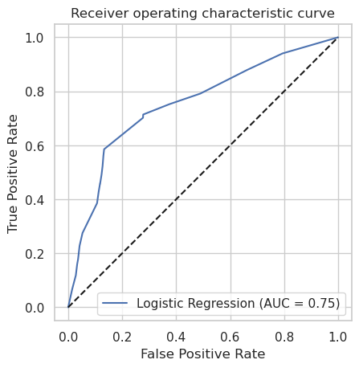

```python
X = binning_process.transform(X_test, metric = "woe")
X2 = sm.add_constant(X)
preds = result.predict(X2)
y = y_test['y'].values

logit_roc_auc = roc_auc_score(y, preds)
fpr, tpr, thresholds = roc_curve(y, preds)
plt.figure()
plt.plot(fpr, tpr, label='Logistic Regression (AUC = %0.2f)' % logit_roc_auc)
plt.plot([0, 1], [0, 1],'k--')
plt.xlim([0.0, 1.0])
plt.ylim([0.0, 1.05])
plt.axis("square")
plt.xlabel('False Positive Rate')
plt.ylabel('True Positive Rate')
plt.title('Receiver operating characteristic curve')
plt.legend(loc="lower right")
plt.show()
```

```python
from sklearn import tree
from sklearn.neighbors import KNeighborsClassifier
```

```python
all_variables = data.columns
all_dependent_variables = list(all_variables)
all_dependent_variables.remove('y')

numeric_variables = []
category_variables = []

dtypes_dict = dict(data[all_dependent_variables].dtypes)

for key, value in dtypes_dict.items():
    if value == 'object':
        category_variables.append(key)
    else:
        numeric_variables.append(key)

print(category_variables)
print(numeric_variables)
```

```
['job', 'marital', 'education', 'default', 'housing', 'loan', 'contact', 'month', 'day_of_week', 'poutcome']
['age', 'duration', 'campaign', 'pdays', 'previous', 'emp_var_rate', 'cons_price_idx', 'cons_conf_idx', 'euribor3m', 'nr_employed']
```

```python
import category_encoders as ce

X = X_train
X2 = X_test
y = y_train['y'].values

ce_target = ce.TargetEncoder(cols = category_variables)
ce_target.fit(X, y)
XTE = ce_target.transform(X)
XTE2 = ce_target.transform(X2)
display(XTE)
```

|  | age | job | marital | education | default | housing | loan | contact | month | day_of_week | duration | campaign | pdays | previous | poutcome | emp_var_rate | cons_price_idx | cons_conf_idx | euribor3m | nr_employed |
| --- | --- | --- | --- | --- | --- | --- | --- | --- | --- | --- | --- | --- | --- | --- | --- | --- | --- | --- | --- | --- |
| 40442 | 38 | 0.112784 | 0.101596 | 0.115741 | 0.129636 | 0.116385 | 0.113252 | 0.052150 | 0.063149 | 0.120787 | 287 | 4 | 999 | 0 | 0.087924 | 1.1 | 93.994 | -36.4 | 4.855 | 5191.0 |
| 26951 | 27 | 0.127483 | 0.100604 | 0.106393 | 0.129636 | 0.108479 | 0.113252 | 0.147258 | 0.063149 | 0.120787 | 244 | 1 | 999 | 1 | 0.146374 | -1.8 | 92.893 | -46.2 | 1.266 | 5099.1 |
| 13935 | 50 | 0.127483 | 0.101596 | 0.138563 | 0.049062 | 0.108479 | 0.109842 | 0.147258 | 0.089618 | 0.099017 | 85 | 9 | 999 | 0 | 0.087924 | 1.4 | 93.918 | -42.7 | 4.962 | 5228.1 |
| 36198 | 37 | 0.112784 | 0.101596 | 0.085890 | 0.129636 | 0.116385 | 0.113252 | 0.147258 | 0.197826 | 0.099017 | 247 | 1 | 999 | 1 | 0.146374 | -1.8 | 93.075 | -47.1 | 1.466 | 5099.1 |
| 20808 | 45 | 0.084497 | 0.100604 | 0.106393 | 0.049062 | 0.108479 | 0.113252 | 0.147258 | 0.089618 | 0.117281 | 210 | 2 | 999 | 0 | 0.087924 | 1.4 | 93.918 | -42.7 | 4.961 | 5228.1 |
| ... | ... | ... | ... | ... | ... | ... | ... | ... | ... | ... | ... | ... | ... | ... | ... | ... | ... | ... | ... | ... |
| 35766 | 47 | 0.069056 | 0.100604 | 0.085890 | 0.049062 | 0.109971 | 0.109971 | 0.052150 | 0.063149 | 0.117281 | 66 | 2 | 999 | 0 | 0.087924 | 1.1 | 93.994 | -36.4 | 4.857 | 5191.0 |
| 31108 | 38 | 0.127483 | 0.142594 | 0.138563 | 0.129636 | 0.116385 | 0.113252 | 0.147258 | 0.106627 | 0.120787 | 118 | 2 | 999 | 0 | 0.087924 | 1.4 | 93.444 | -36.1 | 4.963 | 5228.1 |
| 7820 | 33 | 0.127483 | 0.100604 | 0.138563 | 0.129636 | 0.108479 | 0.113252 | 0.147258 | 0.106627 | 0.114835 | 88 | 1 | 999 | 0 | 0.087924 | 1.4 | 93.444 | -36.1 | 4.964 | 5228.1 |
| 14188 | 35 | 0.084497 | 0.100604 | 0.106393 | 0.129636 | 0.116385 | 0.113252 | 0.147258 | 0.197826 | 0.120787 | 137 | 1 | 999 | 1 | 0.146374 | -1.8 | 93.075 | -47.1 | 1.410 | 5099.1 |
| 23167 | 27 | 0.112784 | 0.142594 | 0.106393 | 0.049062 | 0.108479 | 0.109842 | 0.052150 | 0.063149 | 0.117281 | 351 | 2 | 999 | 0 | 0.087924 | 1.1 | 93.994 | -36.4 | 4.856 | 5191.0 |

28831 rows × 20 columns

```python
decision_tree = tree.DecisionTreeClassifier(criterion = "gini", max_depth = 3)
decision_tree.fit(XTE, y)
```

```
DecisionTreeClassifier(max_depth=3)
```

```python
feature_names = XTE.columns.tolist()
class_ = list(set(y))
class_names = [str(x) for x in class_]

tree_rules = tree.export_text(decision_tree, feature_names = feature_names)
print(tree_rules)
```

```
|--- nr_employed <= 5087.65
|   |--- duration <= 172.50
|   |   |--- pdays <= 11.00
|   |   |   |--- class: 0
|   |   |--- pdays >  11.00
|   |   |   |--- class: 0
|   |--- duration >  172.50
|   |   |--- pdays <= 16.50
|   |   |   |--- class: 1
|   |   |--- pdays >  16.50
|   |   |   |--- class: 1
|--- nr_employed >  5087.65
|   |--- duration <= 528.50
|   |   |--- month <= 0.33
|   |   |   |--- class: 0
|   |   |--- month >  0.33
|   |   |   |--- class: 0
|   |--- duration >  528.50
|   |   |--- duration <= 827.50
|   |   |   |--- class: 0
|   |   |--- duration >  827.50
|   |   |   |--- class: 1
```

[output not shown]

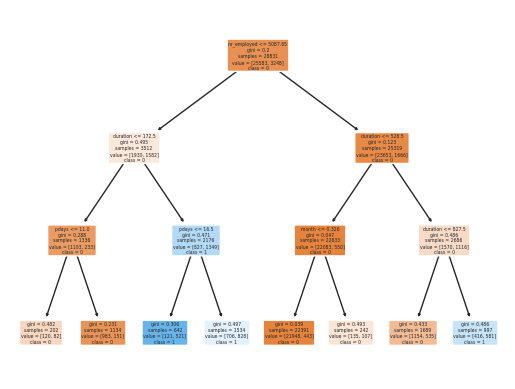

```python
tree.plot_tree(decision_tree
          , feature_names = feature_names
          , class_names = class_names
          , filled = True
          , rounded = True)
```

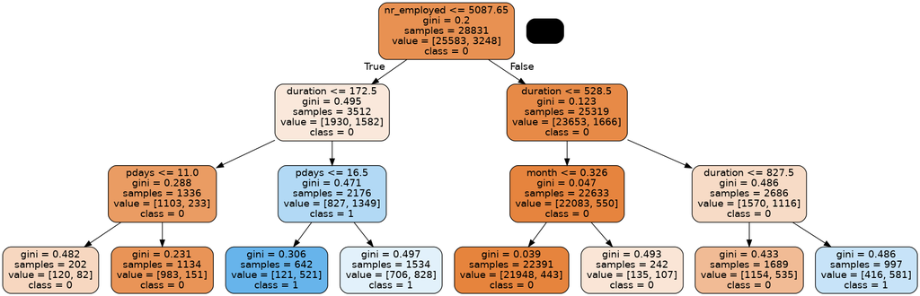

```python
import pydotplus
from IPython.display import Image

dot_data = tree.export_graphviz(decision_tree
                                , out_file = None
                                , feature_names = feature_names
                                , class_names = class_names
                                , filled = True
                                , rounded = True)

graph = pydotplus.graph_from_dot_data(dot_data)
Image(graph.create_png())
```

```python
y = y_test['y'].values
probs = decision_tree.predict_proba(XTE2)
preds = probs[:,1]

# Calculate the false positive rate (FPR), true positive rate (TPR), and thresholds
fpr, tpr, thresholds = roc_curve(y, preds)

# Calculate the AUC (Area Under the Curve)
roc_auc = auc(fpr, tpr)
gini = 2.0*roc_auc-1.0
print('Fit statistics of decision tree classifier on test set')
print('AUC:', round(roc_auc, 5))
print('Gini:', round(gini, 5))
```

```
Fit statistics of decision tree classifier on test set
AUC: 0.86818
Gini: 0.73636
```

```python
X = X_train
X2 = X_test
y = y_train['y'].values

ce_target = ce.TargetEncoder(cols = category_variables)
ce_target.fit(X, y)
XTE = ce_target.transform(X)
XTE2 = ce_target.transform(X2)
```

```python
from sklearn.feature_selection import SelectKBest
from sklearn.feature_selection import f_classif
```

```python
cols = list(XTE.columns)
cols_selector = []
selector = SelectKBest(f_classif, k = 5)
selector.fit(XTE, y)
cols_idxs = selector.get_support(indices=True)

for x in cols_idxs:
    cols_selector.append(cols[x])

XTES = selector.transform(XTE)
XTES = pd.DataFrame(XTES)
XTES.columns = cols_selector

XTE2S = selector.transform(XTE2)
XTE2S = pd.DataFrame(XTE2S)
XTE2S.columns = cols_selector

display(XTES)
```

|  | duration | pdays | poutcome | euribor3m | nr_employed |
| --- | --- | --- | --- | --- | --- |
| 0 | 287.0 | 999.0 | 0.087924 | 4.855 | 5191.0 |
| 1 | 244.0 | 999.0 | 0.146374 | 1.266 | 5099.1 |
| 2 | 85.0 | 999.0 | 0.087924 | 4.962 | 5228.1 |
| 3 | 247.0 | 999.0 | 0.146374 | 1.466 | 5099.1 |
| 4 | 210.0 | 999.0 | 0.087924 | 4.961 | 5228.1 |
| ... | ... | ... | ... | ... | ... |
| 28826 | 66.0 | 999.0 | 0.087924 | 4.857 | 5191.0 |
| 28827 | 118.0 | 999.0 | 0.087924 | 4.963 | 5228.1 |
| 28828 | 88.0 | 999.0 | 0.087924 | 4.964 | 5228.1 |
| 28829 | 137.0 | 999.0 | 0.146374 | 1.410 | 5099.1 |
| 28830 | 351.0 | 999.0 | 0.087924 | 4.856 | 5191.0 |

28831 rows × 5 columns

```python
from sklearn.preprocessing import StandardScaler
from sklearn.neural_network import MLPClassifier
```

```python
y = y_train['y'].values

scaler = StandardScaler()
scaler.fit(XTES)

XTESS = scaler.transform(XTES)
XTESS = pd.DataFrame(XTESS)
XTESS.columns = cols_selector

XTE2SS = scaler.transform(XTE2S)
XTE2SS = pd.DataFrame(XTE2SS)
XTE2SS.columns = cols_selector

display(XTESS)
```

|  | duration | pdays | poutcome | euribor3m | nr_employed |
| --- | --- | --- | --- | --- | --- |
| 0 | 0.110899 | 0.195941 | -0.243841 | 0.712892 | 0.333553 |
| 1 | -0.055258 | 0.195941 | 0.332423 | -1.354284 | -0.936399 |
| 2 | -0.669651 | 0.195941 | -0.243841 | 0.774521 | 0.846233 |
| 3 | -0.043665 | 0.195941 | 0.332423 | -1.239089 | -0.936399 |
| 4 | -0.186637 | 0.195941 | -0.243841 | 0.773945 | 0.846233 |
| ... | ... | ... | ... | ... | ... |
| 28826 | -0.743070 | 0.195941 | -0.243841 | 0.714044 | 0.333553 |
| 28827 | -0.542136 | 0.195941 | -0.243841 | 0.775097 | 0.846233 |
| 28828 | -0.658059 | 0.195941 | -0.243841 | 0.775673 | 0.846233 |
| 28829 | -0.468718 | 0.195941 | 0.332423 | -1.271343 | -0.936399 |
| 28830 | 0.358202 | 0.195941 | -0.243841 | 0.713468 | 0.333553 |

28831 rows × 5 columns

```python
mlp = MLPClassifier(hidden_layer_sizes=(30, 20, 10), max_iter = 100)
mlp.fit(XTESS, y)

predictions = mlp.predict(XTE2SS)
y = y_test['y'].values
tab = pd.crosstab(y, predictions)
print(tab)
```

```
col_0      0    1
row_0
0      10517  448
1        664  728
```

```python
from sklearn.model_selection import GridSearchCV
```

```python
y = y_train['y'].values

mlp = MLPClassifier(max_iter = 50)

parameter_space = {
    'hidden_layer_sizes': [(30,30,30), (20,10,5), (30,20,10)],
    'activation': ['tanh', 'relu'],
    'solver': ['sgd', 'adam'],
    'alpha': [0.0001, 0.05],
    'learning_rate': ['constant','adaptive'],
}

clf = GridSearchCV(mlp, parameter_space, n_jobs=-1, cv=3)
clf.fit(XTESS, y)

print('Best parameters found:\n', clf.best_params_)

predictions = clf.predict(XTE2S)
y = y_test['y'].values
tab = pd.crosstab(y, predictions)
print(tab)
```

[output not shown]

[output cut: 233 more lines]

[output not shown]

```
Best parameters found:
 {'activation': 'relu', 'alpha': 0.0001, 'hidden_layer_sizes': (20, 10, 5), 'learning_rate': 'adaptive', 'solver': 'adam'}
col_0      1
row_0
0      10965
1       1392
```

```python
from sklearn.neural_network import MLPClassifier
from sklearn.neighbors import KNeighborsClassifier
from sklearn.svm import SVC
from sklearn.gaussian_process import GaussianProcessClassifier
from sklearn.tree import DecisionTreeClassifier
from sklearn.ensemble import RandomForestClassifier, AdaBoostClassifier
from sklearn.naive_bayes import GaussianNB
from sklearn.discriminant_analysis import QuadraticDiscriminantAnalysis
from sklearn.model_selection import cross_val_score
```

```python
X = X_train
X2 = X_test
y = y_train['y'].values

ce_target = ce.TargetEncoder(cols = category_variables)
ce_target.fit(X, y)
XTE = ce_target.transform(X)
XTE2 = ce_target.transform(X2)
```

```python
names = [
    "Nearest Neighbors",
    "Linear SVM",
    "RBF SVM",
    "Gaussian Process",
    "Decision Tree",
    "Random Forest",
    "Neural Net",
    "AdaBoost",
    "Naive Bayes",
    "QDA"
]

classifiers = [
    {'name': "Nearest Neighbors", 'model': KNeighborsClassifier()},
    {'name': "Linear SVM",        'model': SVC(kernel="linear")},
    {'name': "RBF SVM",           'model': SVC(kernel="rbf")},
    {'name': "Gaussian Process",  'model': GaussianProcessClassifier()},
    {'name': "Decision Tree",     'model': DecisionTreeClassifier()},
    {'name': "Random Forest",     'model': RandomForestClassifier()},
    {'name': "Neural Net",        'model': MLPClassifier()},
    {'name': "AdaBoost",          'model': AdaBoostClassifier()},
    {'name': "Naive Bayes",       'model': GaussianNB()},
    {'name': "QDA",               'model': QuadraticDiscriminantAnalysis()},
]

for classifier in classifiers:
    model = classifier['model']
    name = classifier['name']

    scores = cross_val_score(model, XTE, y, cv=5)

    accuracy = 100 * scores.mean()
    stdev = 100 * scores.std()

    print(f'{name:>20} | Accuracy: {accuracy:.2f}% (+/- {stdev:.2f}%)')
```

[output not shown]